# assign3

## STAT3612: Statistical Machine Learning

### Assignment 3: Tree-based Methods, PCA, KNN and SVM

### DUE: Dec 01, 2024, Sunday, 11:59 PM

```python
from google.colab import drive
drive.mount('/content/drive')
```

```python
import pandas as pd

df = pd.read_csv("/content/drive/MyDrive/STAT3612/heart.csv")
```

```python
df.head()
```

|  | Age | Sex | ChestPainType | RestingBP | Cholesterol | FastingBS | RestingECG | MaxHR | ExerciseAngina | Oldpeak | ST_Slope | HeartDisease |
| --- | --- | --- | --- | --- | --- | --- | --- | --- | --- | --- | --- | --- |
| 0 | 40 | M | ATA | 140 | 289 | 0 | Normal | 172 | N | 0.0 | Up | 0 |
| 1 | 49 | F | NAP | 160 | 180 | 0 | Normal | 156 | N | 1.0 | Flat | 1 |
| 2 | 37 | M | ATA | 130 | 283 | 0 | ST | 98 | N | 0.0 | Up | 0 |
| 3 | 48 | F | ASY | 138 | 214 | 0 | Normal | 108 | Y | 1.5 | Flat | 1 |
| 4 | 54 | M | NAP | 150 | 195 | 0 | Normal | 122 | N | 0.0 | Up | 0 |

```python
df['newSex'] = df['Sex'].map({'M': 1,'F': 0})
df['newChestPainType'] = df['ChestPainType'].map({'ASY':3, 'NAP':2, 'ATA': 1,'TA': 0})
df['newRestingECG'] = df['RestingECG'].map({'LVH':2, 'ST': 1,'Normal': 0})
df['newExerciseAngina'] = df['ExerciseAngina'].map({'Y': 1,'N': 0})
df['newST_Slope'] = df['ST_Slope'].map({'Down':2, 'Up': 1,'Flat': 0})
df.drop('Sex', axis=1, inplace=True)
df.drop('ChestPainType', axis=1, inplace=True)
df.drop('RestingECG', axis=1, inplace=True)
df.drop('ExerciseAngina', axis=1, inplace=True)
df.drop('ST_Slope', axis=1, inplace=True)
df
```

|  | Age | RestingBP | Cholesterol | FastingBS | MaxHR | Oldpeak | HeartDisease | newSex | newChestPainType | newRestingECG | newExerciseAngina | newST_Slope |
| --- | --- | --- | --- | --- | --- | --- | --- | --- | --- | --- | --- | --- |
| 0 | 40 | 140 | 289 | 0 | 172 | 0.0 | 0 | 1 | 1 | 0 | 0 | 1 |
| 1 | 49 | 160 | 180 | 0 | 156 | 1.0 | 1 | 0 | 2 | 0 | 0 | 0 |
| 2 | 37 | 130 | 283 | 0 | 98 | 0.0 | 0 | 1 | 1 | 1 | 0 | 1 |
| 3 | 48 | 138 | 214 | 0 | 108 | 1.5 | 1 | 0 | 3 | 0 | 1 | 0 |
| 4 | 54 | 150 | 195 | 0 | 122 | 0.0 | 0 | 1 | 2 | 0 | 0 | 1 |
| ... | ... | ... | ... | ... | ... | ... | ... | ... | ... | ... | ... | ... |
| 913 | 45 | 110 | 264 | 0 | 132 | 1.2 | 1 | 1 | 0 | 0 | 0 | 0 |
| 914 | 68 | 144 | 193 | 1 | 141 | 3.4 | 1 | 1 | 3 | 0 | 0 | 0 |
| 915 | 57 | 130 | 131 | 0 | 115 | 1.2 | 1 | 1 | 3 | 0 | 1 | 0 |
| 916 | 57 | 130 | 236 | 0 | 174 | 0.0 | 1 | 0 | 1 | 2 | 0 | 0 |
| 917 | 38 | 138 | 175 | 0 | 173 | 0.0 | 0 | 1 | 2 | 0 | 0 | 1 |

918 rows × 12 columns

```python
df.info()
```

```
<class 'pandas.core.frame.DataFrame'>
RangeIndex: 918 entries, 0 to 917
Data columns (total 12 columns):
 #   Column             Non-Null Count  Dtype
---  ------             --------------  -----
 0   Age                918 non-null    int64
 1   RestingBP          918 non-null    int64
 2   Cholesterol        918 non-null    int64
 3   FastingBS          918 non-null    int64
 4   MaxHR              918 non-null    int64
 5   Oldpeak            918 non-null    float64
 6   HeartDisease       918 non-null    int64
 7   newSex             918 non-null    int64
 8   newChestPainType   918 non-null    int64
 9   newRestingECG      918 non-null    int64
 10  newExerciseAngina  918 non-null    int64
 11  newST_Slope        918 non-null    int64
dtypes: float64(1), int64(11)
memory usage: 86.2 KB
```

```python
X=df.drop('HeartDisease',axis=1)
Y=df['HeartDisease']
```

#### Part 1: Tree-based Methods

```python
# Q1 (a)

# ------------------
from sklearn.model_selection import train_test_split
from sklearn.tree import DecisionTreeClassifier

X_train, X_test, y_train, y_test = train_test_split(X, Y, test_size=0.4, random_state=2024)

print(f"Training data shape: {X_train.shape}")
print(f"Testing data shape: {X_test.shape}")
# ------------------
```

```
Training data shape: (550, 11)
Testing data shape: (368, 11)
```

```python
# Q1 (b)

# ------------------
from sklearn.preprocessing import MinMaxScaler

scaler = MinMaxScaler(feature_range=(-1, 1))

X_train_scaled = scaler.fit_transform(X_train)
X_test_scaled = scaler.transform(X_test)
# ------------------
```

```python
# Q1 (c)

# ------------------
from sklearn.tree import DecisionTreeClassifier
from sklearn.metrics import classification_report

dt_classifier_entropy = DecisionTreeClassifier(criterion='entropy', max_depth=3, random_state=2024)

dt_classifier_entropy.fit(X_train_scaled, y_train)

y_pred_entropy = dt_classifier_entropy.predict(X_test_scaled)

print("Classification Report:\n", classification_report(y_test, y_pred_entropy))
# ------------------
```

```
Classification Report:
               precision    recall  f1-score   support

           0       0.76      0.82      0.79       164
           1       0.84      0.79      0.82       204

    accuracy                           0.80       368
   macro avg       0.80      0.81      0.80       368
weighted avg       0.81      0.80      0.80       368
```

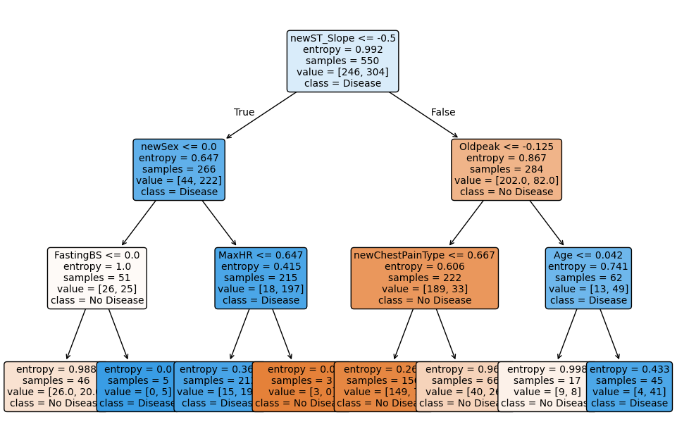

```
Training Accuracy: 0.8545454545454545
Testing Accuracy: 0.8043478260869565
```

```python
# Q1 (d)

# ------------------
from sklearn.tree import plot_tree
import matplotlib.pyplot as plt
from sklearn.metrics import accuracy_score

plt.figure(figsize=(12, 8))
plot_tree(
    dt_classifier_entropy,
    feature_names=X.columns,
    class_names=['No Disease', 'Disease'],
    filled=True,
    rounded=True,
    fontsize=10
)
plt.show()

y_train_pred_entropy = dt_classifier_entropy.predict(X_train_scaled)
train_accuracy = accuracy_score(y_train, y_train_pred_entropy)
test_accuracy = accuracy_score(y_test, y_pred_entropy)

print(f"Training Accuracy: {train_accuracy}")
print(f"Testing Accuracy: {test_accuracy}")
# ------------------
```

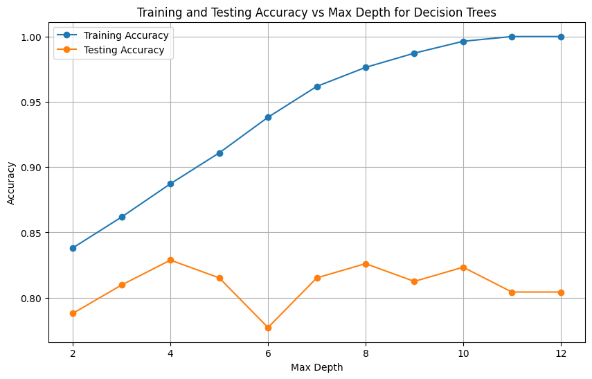

```
The test score achieves its maximum at max_depth=4 with a maximum score of 0.8288043478260869.
```

```python
# Q2 (a)

# ------------------
import numpy as np
from sklearn.metrics import accuracy_score

train_accuracies = []
test_accuracies = []

max_depth_values = range(2, 13)
for depth in max_depth_values:
    dt = DecisionTreeClassifier(max_depth=depth, random_state=2024)
    dt.fit(X_train_scaled, y_train)

    y_train_pred = dt.predict(X_train_scaled)
    y_test_pred = dt.predict(X_test_scaled)

    train_accuracies.append(accuracy_score(y_train, y_train_pred))
    test_accuracies.append(accuracy_score(y_test, y_test_pred))

plt.figure(figsize=(10, 6))
plt.plot(max_depth_values, train_accuracies, label="Training Accuracy", marker='o')
plt.plot(max_depth_values, test_accuracies, label="Testing Accuracy", marker='o')
plt.xlabel("Max Depth")
plt.ylabel("Accuracy")
plt.title("Training and Testing Accuracy vs Max Depth for Decision Trees")
plt.legend()
plt.grid(True)
plt.show()

max_test_accuracy = max(test_accuracies)
optimal_depth = max_depth_values[np.argmax(test_accuracies)]

print(f"\nThe test score achieves its maximum at max_depth={optimal_depth} with a maximum score of {max_test_accuracy}.")
# ------------------
```

I don't think we should continue increasing the depth since the model achieved the best test score at depth = 4 and increasing the depth from 5 to 12 did not improve its test score, even though the training score keeps improving. Hence, a diminished return is observed. Moreover, it can be speculated that as depth increase, the risk of overfitting also increases, decreasing the generalization of the model.

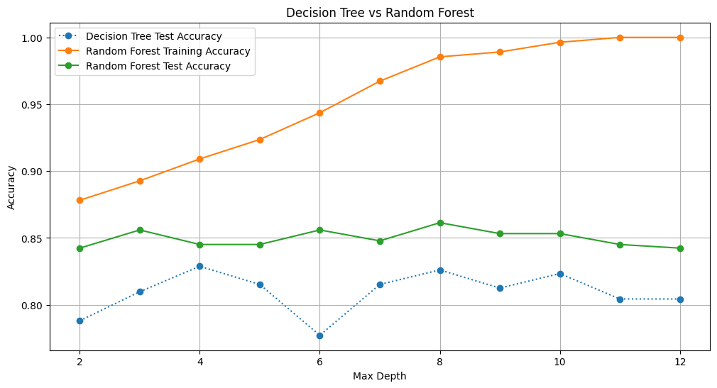

```
The test score achieves its maximum at max_depth=8 with a maximum score of 0.8614130434782609.
```

```python
# Q2 (b)

# ------------------
from sklearn.ensemble import RandomForestClassifier

rf_train_accuracies = []
rf_test_accuracies = []

for depth in range(2, 13):
    rf = RandomForestClassifier(
        n_estimators=80,
        random_state=2024,
        max_features=4,
        max_depth=depth
    )
    rf.fit(X_train_scaled, y_train)

    y_train_pred_rf = rf.predict(X_train_scaled)
    y_test_pred_rf = rf.predict(X_test_scaled)

    rf_train_accuracies.append(accuracy_score(y_train, y_train_pred_rf))
    rf_test_accuracies.append(accuracy_score(y_test, y_test_pred_rf))

plt.figure(figsize=(12, 6))

plt.plot(max_depth_values, test_accuracies, label="Decision Tree Test Accuracy", marker='o', linestyle='dotted')
plt.plot(max_depth_values, rf_train_accuracies, label="Random Forest Training Accuracy", marker='o')
plt.plot(max_depth_values, rf_test_accuracies, label="Random Forest Test Accuracy", marker='o')

plt.xlabel("Max Depth")
plt.ylabel("Accuracy")
plt.title("Decision Tree vs Random Forest")
plt.legend()
plt.grid(True)
plt.show()

max_test_accuracy = max(rf_test_accuracies)
optimal_depth = max_depth_values[np.argmax(rf_test_accuracies)]

print(f"\nThe test score achieves its maximum at max_depth={optimal_depth} with a maximum score of {max_test_accuracy}.")
# ------------------
```

I don't think we should continue increasing the depth since the model achieved the best test score at depth = 8 and increasing the depth from 9 to 12 did not improve its test score, even though the training score keeps improving. Hence, a diminished return is observed. Moreover, it can be speculated that as depth increase, the risk of overfitting also increases, decreasing the generalization of the model.

#### Part 3: PCA and K-Nearest Neighbors

```python
# Q3 (a)

# ------------------
from sklearn.neighbors import KNeighborsClassifier

knn_classifier = KNeighborsClassifier()
knn_classifier.fit(X_train_scaled, y_train)

y_pred_knn = knn_classifier.predict(X_test_scaled)

knn_test_accuracy = accuracy_score(y_test, y_pred_knn)
print(f"KNN Test Accuracy: {knn_test_accuracy}")
# ------------------
```

```
KNN Test Accuracy: 0.8478260869565217
```

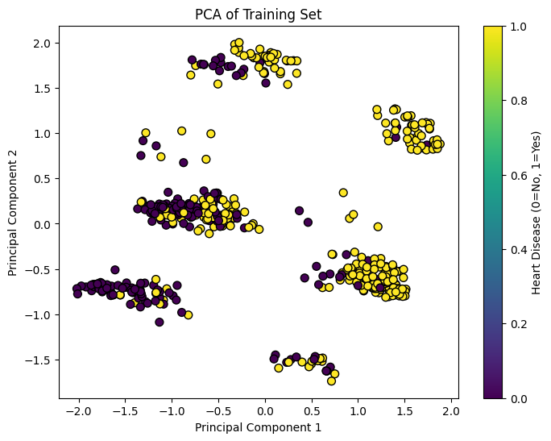

```python
# Q3 (b)

# ------------------
from sklearn.decomposition import PCA

pca = PCA(n_components=2)

X_train_pca = pca.fit_transform(X_train_scaled)
X_test_pca = pca.transform(X_test_scaled)

plt.figure(figsize=(8, 6))
scatter = plt.scatter(X_train_pca[:, 0], X_train_pca[:, 1], c=y_train, cmap='viridis', edgecolor='k', s=50)

plt.colorbar(scatter, label="Heart Disease (0=No, 1=Yes)")
plt.title("PCA of Training Set")
plt.xlabel("Principal Component 1")
plt.ylabel("Principal Component 2")
plt.show()
# ------------------
```

```python
# Q3 (c)

# ------------------
knn_pca_classifier = KNeighborsClassifier()

knn_pca_classifier.fit(X_train_pca, y_train)

y_pred_knn_pca = knn_pca_classifier.predict(X_test_pca)

knn_pca_test_accuracy = accuracy_score(y_test, y_pred_knn_pca)
print(f"KNN Test Accuracy on PCA-transformed data: {knn_pca_test_accuracy}")
print(f"KNN Test Accuracy: {knn_test_accuracy}")
# ------------------
```

```
KNN Test Accuracy on PCA-transformed data: 0.8152173913043478
KNN Test Accuracy: 0.8478260869565217
```

The original KNN has a higher test accuracy than KNN using PCA-transformed data. Reducing the data to only two principal components might have caused loss of information. So though the dimensionality is reduced, crucial information of the data has been lost, leading to the decreased test accuracy.

#### Part 4: Support Vector Machine

```python
# Q4 (a)

# ------------------
from sklearn.preprocessing import StandardScaler
from sklearn.svm import SVC
from sklearn.metrics import accuracy_score

X_svm = df[['Age', 'RestingBP']]
y_svm = df['HeartDisease']

scaler = StandardScaler()
X_svm_scaled = scaler.fit_transform(X_svm)

svm_classifier = SVC(random_state=2024)
svm_classifier.fit(X_svm_scaled, y_svm)

X_test_svm = X_test[['Age', 'RestingBP']]
X_test_svm_scaled = scaler.transform(X_test_svm)
y_pred_svm = svm_classifier.predict(X_test_svm_scaled)

svm_test_accuracy = accuracy_score(y_test, y_pred_svm)
print(f"SVM Test Accuracy: {svm_test_accuracy}")
# ------------------
```

```
SVM Test Accuracy: 0.654891304347826
```

```python
# Q4 (b)

# ------------------
X = df[['Age', 'RestingBP']]
y = df['HeartDisease']

X_train, X_test, y_train, y_test = train_test_split(X, y, test_size=0.3, random_state=2024)

scaler = StandardScaler()
X_train_scaled = scaler.fit_transform(X_train)
X_test_scaled = scaler.transform(X_test)

svm_classifier = SVC(C=1.5, kernel='rbf', random_state=2024)
svm_classifier.fit(X_train_scaled, y_train)
y_pred_svm = svm_classifier.predict(X_test_scaled)

svm_test_accuracy = accuracy_score(y_test, y_pred_svm)
print(f"SVM Test Accuracy: {svm_test_accuracy}")
# ------------------
```

```
SVM Test Accuracy: 0.5905797101449275
```

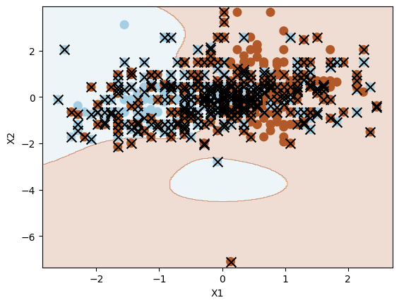

```
Number of support vectors:  484
```

```python
# Q4 (c)

# ------------------
import matplotlib as mpl
def plot_svc(svc, X, y, h=0.02, pad=0.25):
    x_min, x_max = X[:, 0].min() - pad, X[:, 0].max() + pad
    y_min, y_max = X[:, 1].min() - pad, X[:, 1].max() + pad
    xx, yy = np.meshgrid(np.arange(x_min, x_max, h), np.arange(y_min, y_max, h))
    Z = svc.predict(np.c_[xx.ravel(), yy.ravel()])
    Z = Z.reshape(xx.shape)
    plt.contourf(xx, yy, Z, cmap=plt.cm.Paired, alpha=0.2)

    plt.scatter(X[:, 0], X[:, 1], s=70, c=y, cmap=mpl.cm.Paired)
    # Support vectors indicated in plot by vertical lines
    sv = svc.support_vectors_
    plt.scatter(sv[:, 0], sv[:, 1], c='k', marker='x', s=100)
    plt.xlim(x_min, x_max)
    plt.ylim(y_min, y_max)
    plt.xlabel('X1')
    plt.ylabel('X2')
    plt.show()
    print('Number of support vectors: ', svc.support_.size)

plot_svc(svm_classifier, X_train_scaled, y_train)
# ------------------
```

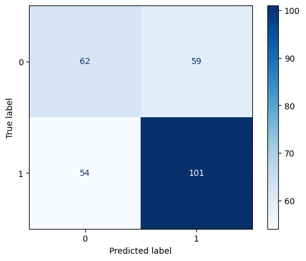

```
Test Accuracy: 0.5905797101449275
```

```python
# Q4 (d)

# ------------------
from sklearn.metrics import confusion_matrix, ConfusionMatrixDisplay

X_test_scaled = scaler.transform(X_test)
y_pred_test = svm_classifier.predict(X_test_scaled)

conf_matrix = confusion_matrix(y_test, y_pred_test)

disp = ConfusionMatrixDisplay(confusion_matrix=conf_matrix, display_labels=svm_classifier.classes_)
disp.plot(cmap=plt.cm.Blues)
plt.show()

test_accuracy = accuracy_score(y_test, y_pred_test)
print(f"Test Accuracy: {test_accuracy}")
# ------------------
```